# Stationarity of Turkish Electricity Consumption Data

İlayda Tutal

25 01 2021

# Introduction

In this study, electricity consumption in Turkey data, which is a non-stationary time series, is aimed to be transformed to a stationary one and make a 2-week long daily prediction with this stationary data. The data is taken from the [EPİAŞ website](https://seffaflik.epias.com.tr/transparency/) as hourly data. To make this transformation, time series data will be analyzed; therefore, differencing, decomposition, necessary tests will be used when needed to reach a “good” model. Detailed explanations will be provided in the related parts. After choosing the best model, predictions will be done y using this model.

Model’s residuals should: * have zero mean and constant variance. * normally distributed. * and not be autocorrelated.

From beginning of the 2017, to 8-Jan-2021 is used as train data; therefore the 2-week period which will be estimated is 9-Jan-2021 to 22-Jan-2021.

# Analysis

## Data Manipulation

First, data is imported and transformed into a data.table and the necessary manipulations are done such as: converting the Date column’s type to “Date” from “chr”, converting the data to a mean consumption data since daily predictions will be made, not hourly.

```
## [1] 27099.66 33141.88 34769.59 35250.70 35109.35 33866.49
```

```
## [1] 1469
```

```
##          Date mean_consumption
## 1: 2017-01-01         27099.66
## 2: 2017-01-02         33141.88
## 3: 2017-01-03         34769.59
## 4: 2017-01-04         35250.70
## 5: 2017-01-05         35109.35
## 6: 2017-01-06         33866.49
```

```
##          Date mean_consumption
## 1: 2021-01-03         30023.36
## 2: 2021-01-04         35548.28
## 3: 2021-01-05         36723.26
## 4: 2021-01-06         37182.32
## 5: 2021-01-07         37299.57
## 6: 2021-01-08         36873.90
```

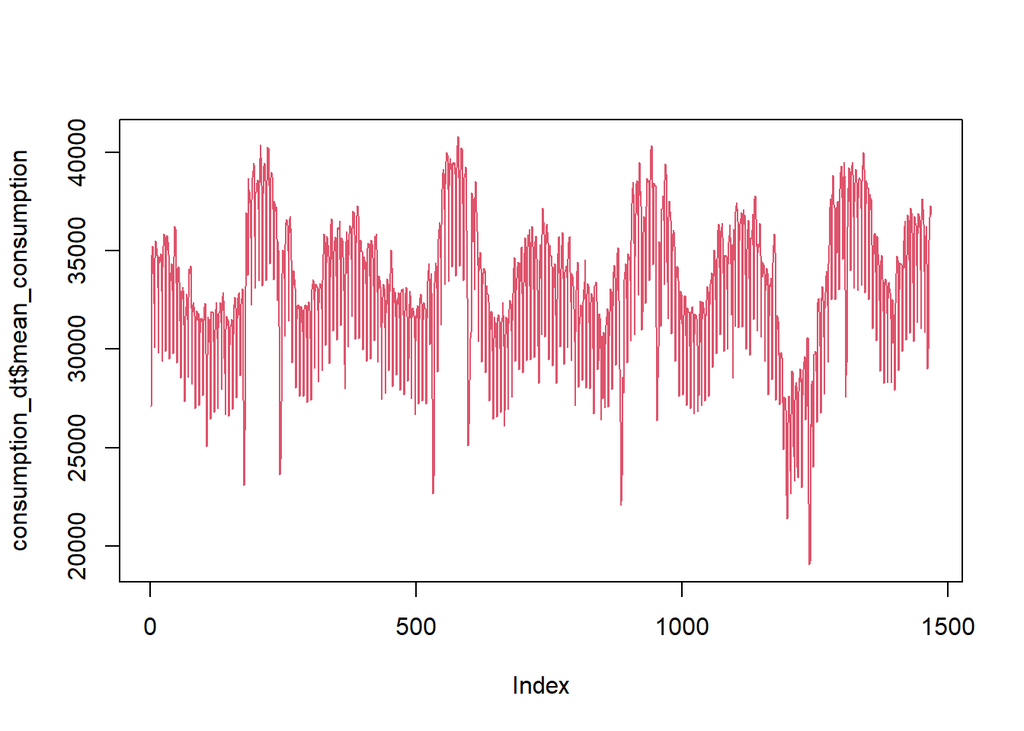

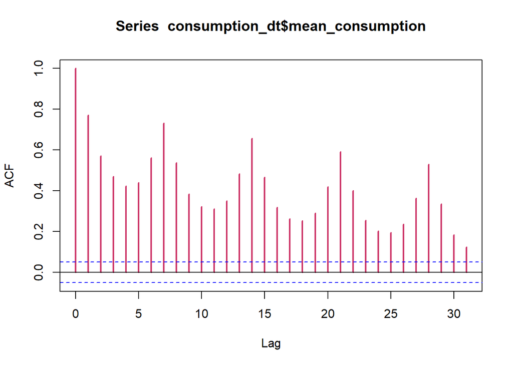

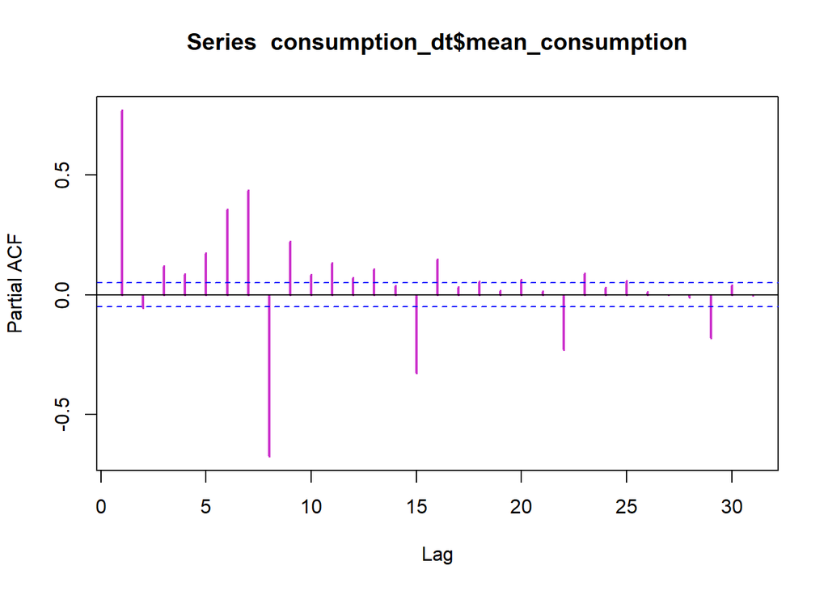

```
##
## #######################
## # KPSS Unit Root Test #
## #######################
##
## Test is of type: mu with 7 lags.
##
## Value of test-statistic is: 0.1457
##
## Critical value for a significance level of:
##                 10pct  5pct 2.5pct  1pct
## critical values 0.347 0.463  0.574 0.739
```

ACF plot shows the seasonality clearly. Although the test statistics of the KPSS unit root test is not higher than the critical values, taking the difference might help to decrease this value. Therefore, the daily consumption are shifted by 7 rows and taken the difference. This might be problematic in the prediction part since 14 days should be predicted, but this problem can be handled and an alternative model could be developed. Here is the plot of the new column:

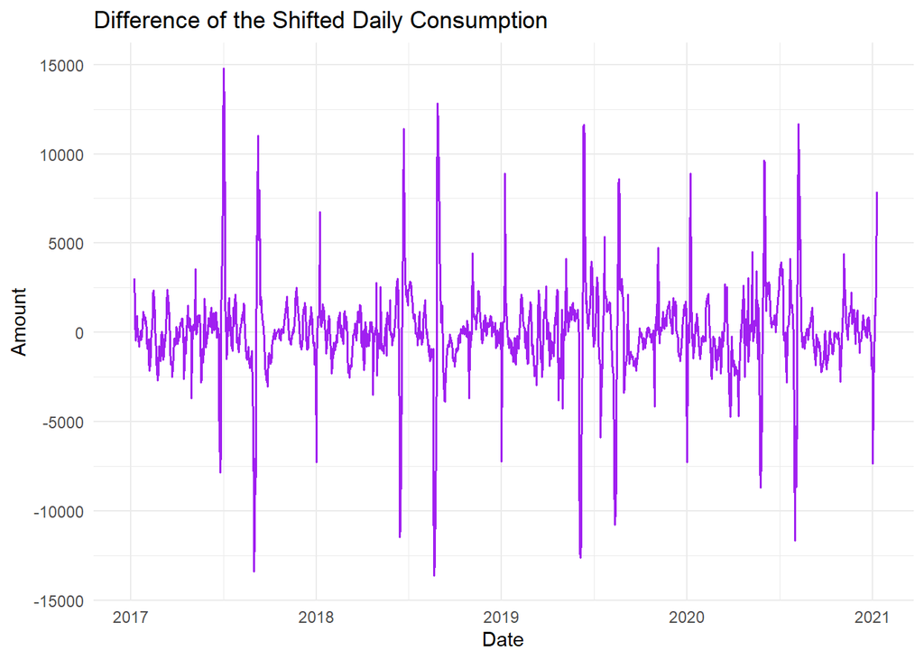

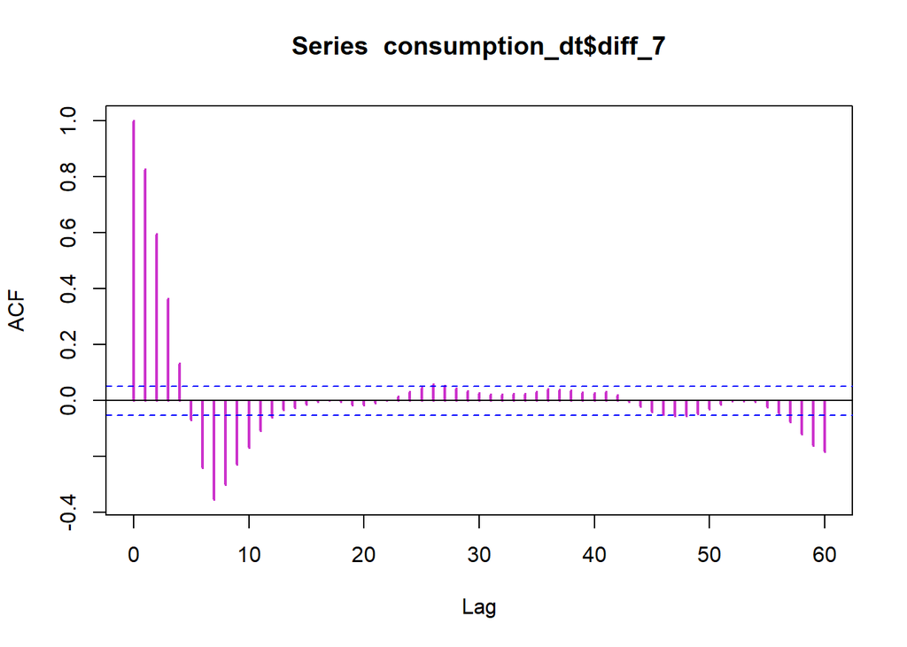

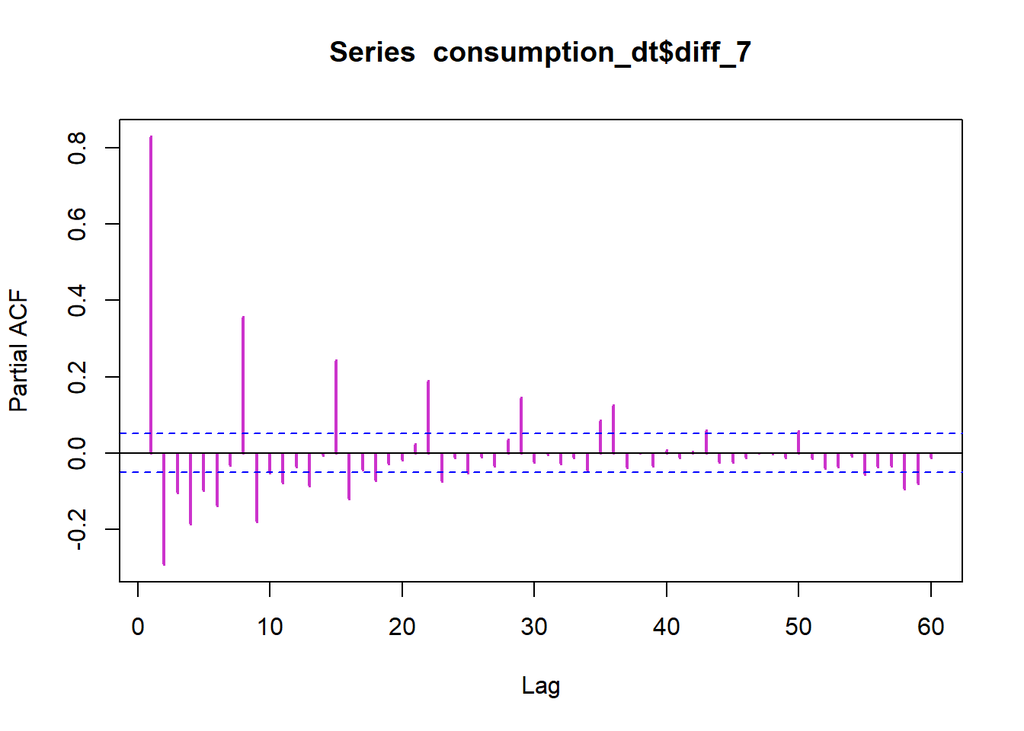

```r
consumption_dt[,lag_7:=shift(mean_consumption,7)]
consumption_dt[,diff_7:=mean_consumption-lag_7 ]
difference <- consumption_dt$diff_7

ggplot(consumption_dt, aes(x=Date, y=diff_7)) + geom_line(size = 0.7, color="purple") +
  labs(title = "Difference of the Shifted Daily Consumption", x = "Date", y = "Amount") +
  theme_minimal()
```

```r
summary(ur.kpss(difference))
```

```
##
## #######################
## # KPSS Unit Root Test #
## #######################
##
## Test is of type: mu with 7 lags.
##
## Value of test-statistic is: 0.0121
##
## Critical value for a significance level of:
##                 10pct  5pct 2.5pct  1pct
## critical values 0.347 0.463  0.574 0.739
```

So, taking the difference helped us to get smaller test statistic which was desired! We can say that we cannot reject the null hypothesis, the data is stationary now. Let’s decompose it with the type “additive”, and fit the randoms into a arima model. In this part, auto.arima function is used to find the best model.

## Model with Differencing

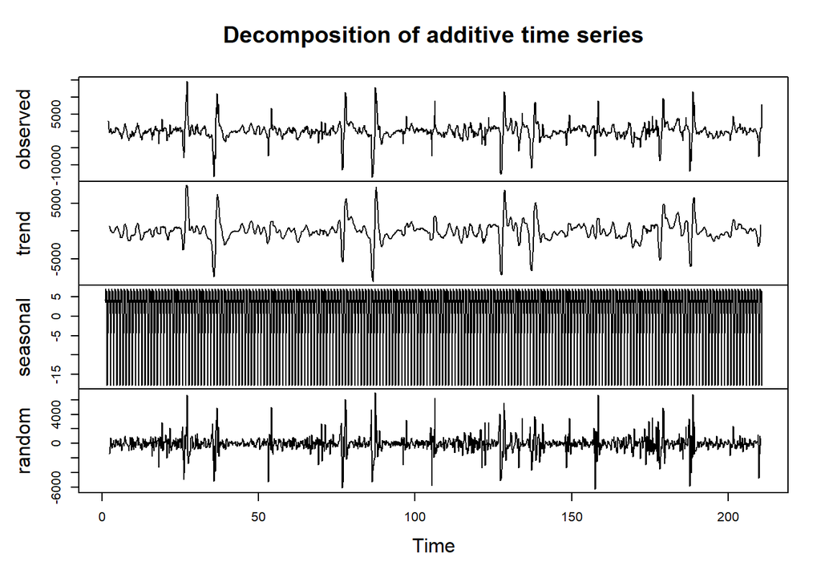

After decomposition, here the plots of the additive model’s random values and the model that auto.arima found for us:

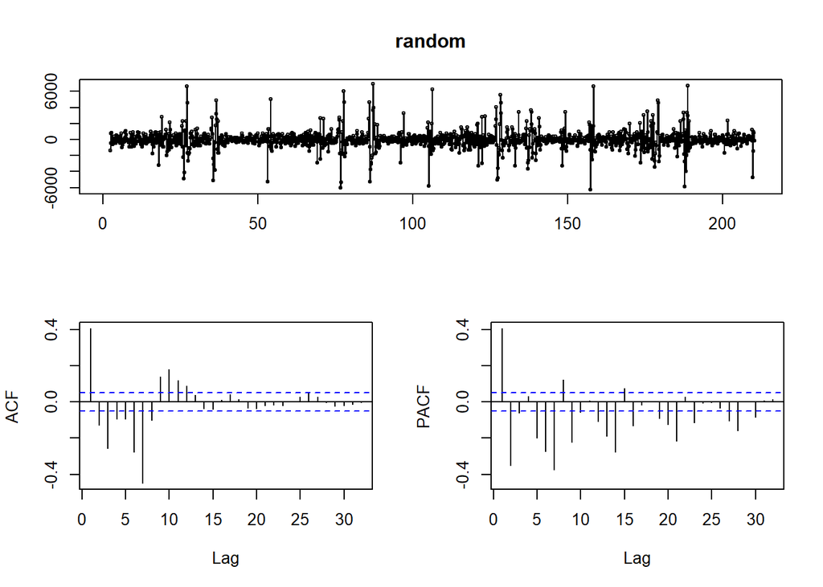

```
## Series: random
## ARIMA(0,0,1)(0,0,1)[7] with non-zero mean
##
## Coefficients:
##          ma1     sma1     mean
##       0.5067  -0.9307  -0.0998
## s.e.  0.0200   0.0091   2.2981
##
## sigma^2 estimated as 616425:  log likelihood=-11777.13
## AIC=23562.25   AICc=23562.28   BIC=23583.39
```

And the results of the model:

```
##
## Call:
## arima(x = random, order = c(0, 0, 1), seasonal = c(0, 0, 1))
##
## Coefficients:
##          ma1     sma1  intercept
##       0.5067  -0.9307    -0.0998
## s.e.  0.0200   0.0091     2.2981
##
## sigma^2 estimated as 615155:  log likelihood = -11777.13,  aic = 23562.25
##
## Training set error measures:
##                     ME     RMSE      MAE      MPE     MAPE      MASE       ACF1
## Training set -1.508931 784.3181 471.7824 298.3209 582.0386 0.6143847 0.02847613
```

# Forecasting with the Model for Differenced Data

In this part, a prediction is going to be made before trying another model. As it is mentioned before, shifting is done with 7 rows; so, we can predict at most 7 rows (7 days) now. To handle this situation, at first, 7 days are predicted. Then, it is assumed that the actual values of this 7 days are %5 more that we predicted. With this assumption, now we can make a 7-day forecast again. Which is actually the second half of our aimed 14-day period.

The %5 assumption is made by observing the cyclic pattern of the last weeks.

## Comparing with the Actual Values

In this part, actual data is taken and compared with the help of a function which provides us statistics such as MAPE, MAD and so on. Also the forecasted part is plotted:

```
##    n     mean       sd       bias       mape      mad      wmape
## 1 14 37045.79 2567.339 0.03661536 0.05323918 2007.737 0.05419608
```

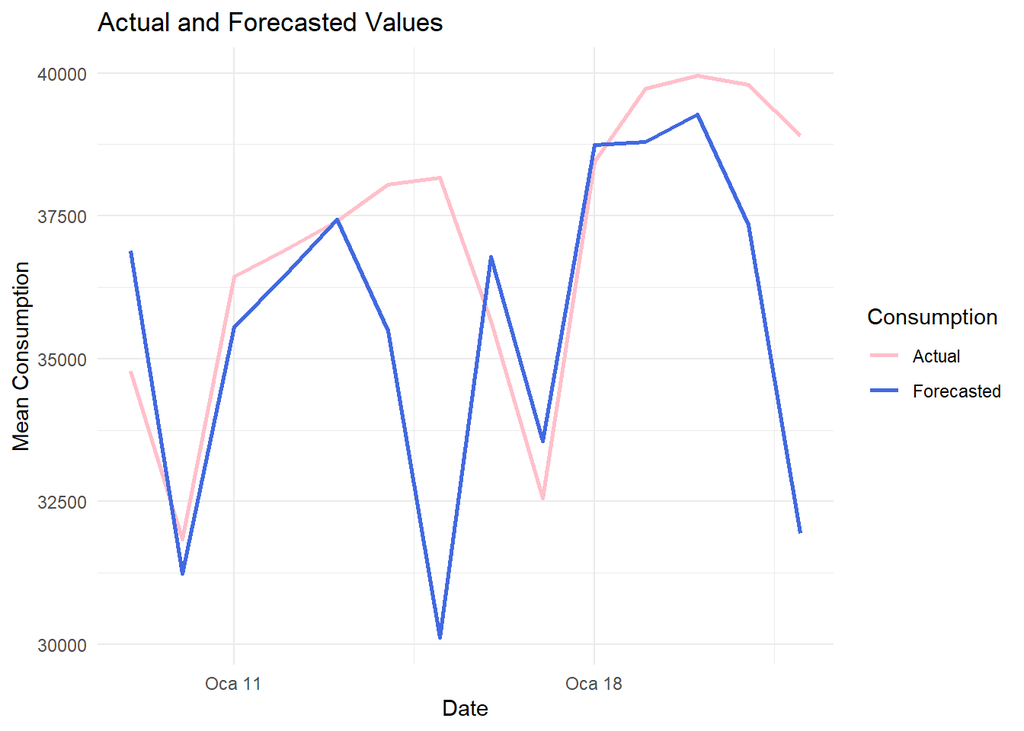

# Modeling without Differencing

The model obtained in the previous part might not be the best, so let’s try another approach. I will decompose it again but to find the arima model, I will continue step by step trying to find which AR and MA order will be the best.

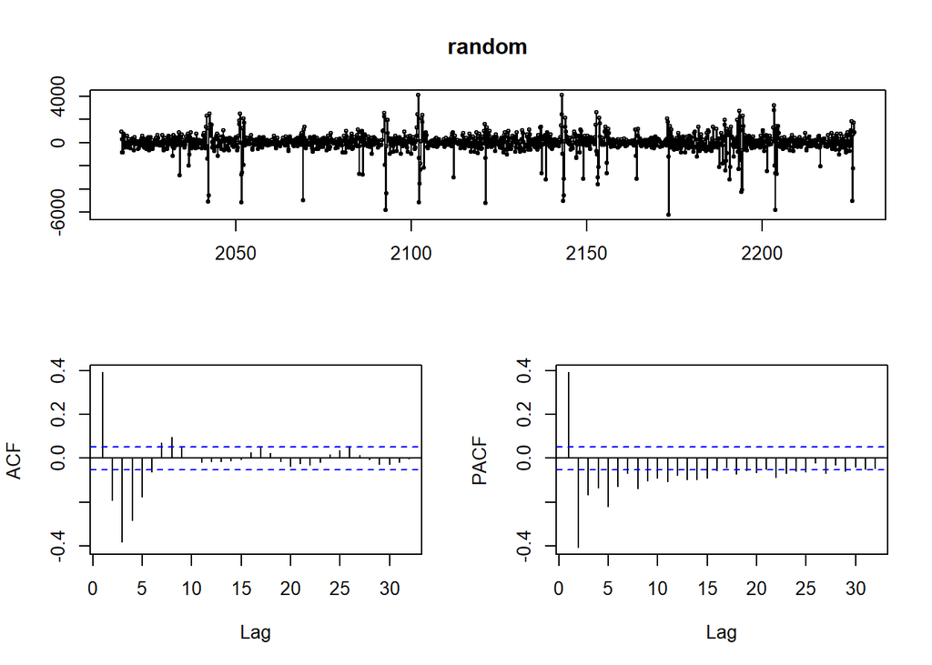

By looking at the random values’ acf and pacf plots, we can see the gradual decay in the PACF which is a sign for MA model. MA(1) or MA(3) can be tried:

```
##
## Call:
## arima(x = random, order = c(0, 0, 1))
##
## Coefficients:
##          ma1  intercept
##       0.5095     0.0899
## s.e.  0.0200    30.1678
##
## sigma^2 estimated as 584644:  log likelihood = -11789.47,  aic = 23584.94
```

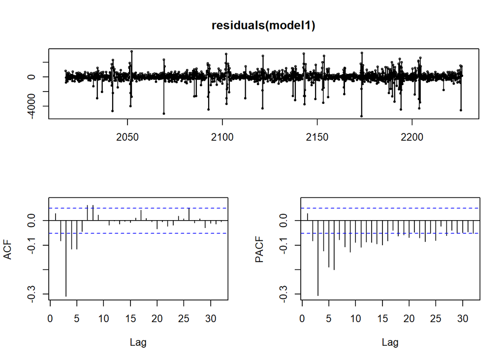

Now a similar situation, let’s add MA(3):

```
##
## Call:
## arima(x = random, order = c(0, 0, 3))
##
## Coefficients:
##          ma1      ma2      ma3  intercept
##       0.1297  -0.5611  -0.5687    -0.0131
## s.e.  0.0198   0.0221   0.0201     0.1118
##
## sigma^2 estimated as 449111:  log likelihood = -11599.81,  aic = 23209.61
```

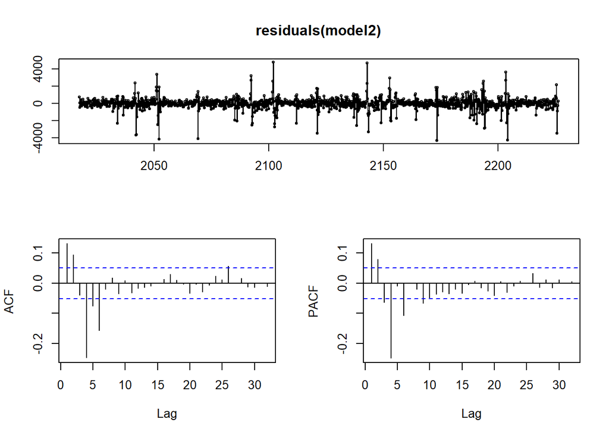

Results are better but there is still AR affect we can add. Try AR(2):

```
##
## Call:
## arima(x = random, order = c(2, 0, 3))
##
## Coefficients:
##          ar1      ar2      ma1      ma2     ma3  intercept
##       1.1993  -0.5851  -0.9747  -0.1373  0.1120    -0.0097
## s.e.  0.0762   0.0409   0.0885   0.0433  0.0666     0.0941
##
## sigma^2 estimated as 411148:  log likelihood = -11535.43,  aic = 23084.85
```

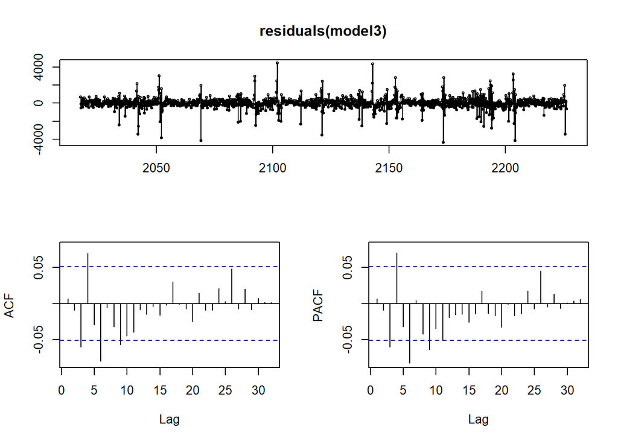

Both plots and test statistic tells us we have reached the best model so far! We have the smallest AIC value. So, I will choose this model.

# Choosing the Best Model

Last model from previous part is chosen.

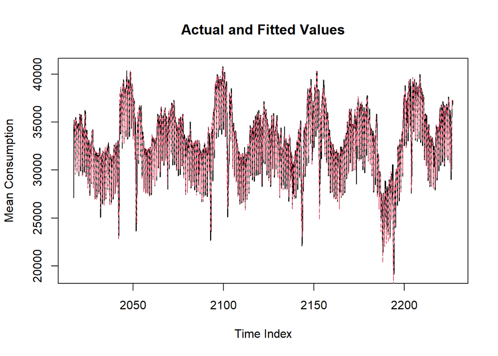

# Forecasting with the ARIMA(2,0,3)

We can forecast now:

```
##    n     mean       sd       bias       mape      mad      wmape
## 1 14 37045.79 2567.339 0.06053073 0.05930967 2242.409 0.06053073
```

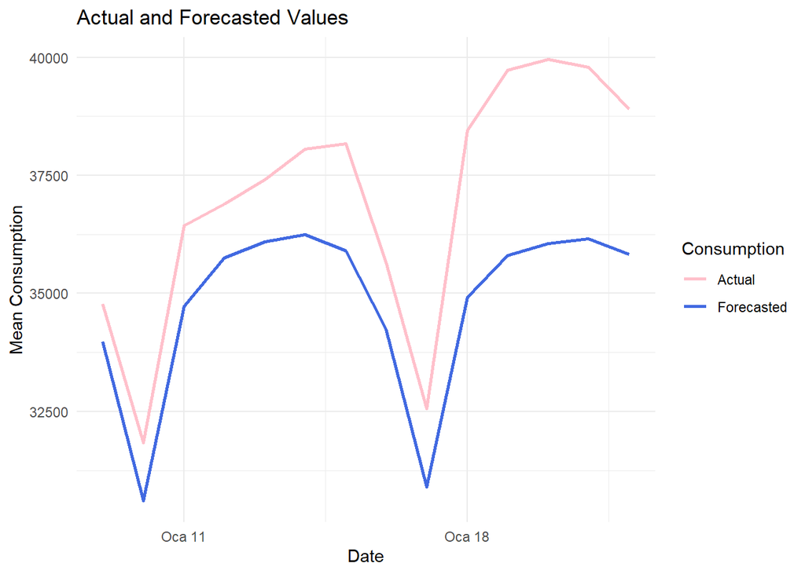

# Conclusion

The data is transformed into a stationary data and 2 alternative models are built. The one with the lowest AIC value is chosen and predictions are made.14 day period is predicted and seen. And lastly, the whole data:

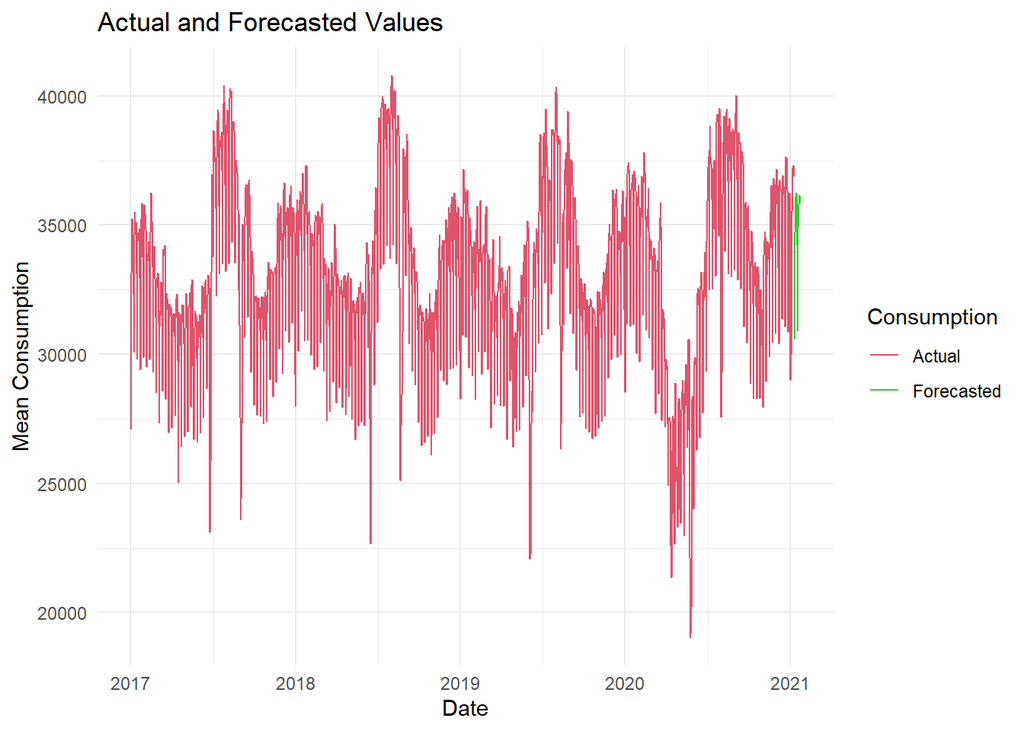

**For the rmd file and codes of this report [click](https://bu-ie-360.github.io/fall20-ilaydatutal/files/Homework4deneme.Rmd)**